# Model1

Several authors

Created: 12-04-2024. Last modified: 14-04-2024.

```css
body .main-container {
  max-width: 100% !important;
  width: 100% !important;
}
body {
  max-width: 100% !important;
}

body, td {
   font-size: 16px;
}
code.r{
  font-size: 14px;
}
pre {
  font-size: 14px
}
```

Let us set some global options for all code chunks in this document.

```r
knitr::opts_chunk$set(
  message = FALSE,    # Disable messages printed by R code chunks
  warning = FALSE,    # Disable warnings printed by R code chunks
  echo = TRUE,        # Show R code within code chunks in output
  include = TRUE,     # Include both R code and its results in output
  eval = TRUE,       # Evaluate R code chunks
  cache = FALSE,       # Enable caching of R code chunks for faster rendering
  fig.align = "center",
  out.width = "100%",
  retina = 2
)
rm(list = ls())
#set.seed(1982)
```

# 1 Preprocessing

Let us now load some required libraries.

```r
# Load required libraries
library(INLA)
library(inlabru)
library(rSPDE)
library(MetricGraph)

library(plotly)
library(dplyr)
library(tidyr)
library(MASS)
library(glmnet)
library(car)
library(ggplot2)
library(plotly)

library(sf)

library(here)
```

We now define some `R` functions with self-explanatory names.

```r
# Functions to manipulate the data
standardize <- function(vector) {return((vector - mean(vector)) / sd(vector))}
minmax_scaling <- function(x) {return((x - min(x)) / (max(x) - min(x)))}
convert_to_binary <- function(input_vector) {return(ifelse(input_vector != 0, 1, 0))}
```

### 1.0.1 Prepare the data

The following chunk uses the function `creates_covariates_on_mesh()` defined on `Preprocessing/28Window.case.file4.addcovariatesonmesh.R` to build a mesh (on the same graph as the one used in this file) and compute the value of all available covariates on the mesh nodes.

Press the `Show` button below if you want to see the body of the `creates_covariates_on_mesh()` function.

```r
creates_covariates_on_mesh = function(h){

  library(MetricGraph)
  library(dplyr)
  # loading the data
  load("Graph_objects/graph_construction_28_03_2024partialtomtomwhichlonglatsf.RData")
  load("Data_files/data_day7142128_hour13_with_no_consecutive_zeros_partialtomtom_graph_processed.RData")
  load("Data_files/stops_data_on_graph_partialtomtom.RData")

  # length of each edge
  edge_length = sf_graph$get_edge_lengths()

  # matrix of vertices, the vertices in the i-th are the vertices that define edge i
  vertex_matrix = sf_graph$E

  sf_graph$add_observations(data = data_on_graph, group = "day", clear_obs = TRUE)

  sf_graph$build_mesh(h = h)

  data_on_mesh = sf_graph$edgeweight_to_data(mesh = TRUE, add = FALSE, return = TRUE) %>% filter(.group == 1)

  data_on_graph = data_on_mesh

  # getting the edge_number and distance_on_edge columns from data
  data_on_graph_red = data.frame(edge_number = data_on_graph$.edge_number,
                                 distance_on_edge = data_on_graph$.distance_on_edge)


  # defining function that decays from 1
  fun = function(x){return(exp(-((x/0.05)^2)))}


  # ------------------------------------------------------------------------------------------------------------------
  # For bus_stop
  # ------------------------------------------------------------------------------------------------------------------



  # getting the sign_data (this could be bus_stop, traffic_signals, stop or crossing)
  sign_data = traffic_stops %>%
    filter(highway == "bus_stop") %>%
    as.data.frame() %>%
    dplyr::select(.edge_number, .distance_on_edge) %>%
    rename(edge_number = .edge_number, distance_on_edge = .distance_on_edge)

  # initializing a vector to store the edges numbers from sign_data (they are not necessarily unique)
  edges = c()

  borderline = 0.1
  # looping over the signs


  list_for_indices = list()
  list_for_indices[[(sf_graph$nE + 1)]] = "tmp1"
  list_for_max_values = list()
  list_for_max_values[[(sf_graph$nE + 1)]] = "tmp2"

  # ----------------------------------------------------------------------------------------------

  for (k in 1:nrow(sign_data)) {
    # getting the sign at iteration i
    sign = sign_data[k,]
    # getting the edge that contains the sign
    edge_number = sign[[1]]
    # storing the edge_number into edges vector
    edges[k] = edge_number
    # getting the distance on the edge of the sign
    distance_on_edge = sign[[2]]

    original_distance = as.numeric(edge_length[edge_number])
    center_sign = original_distance*distance_on_edge
    vertices = vertex_matrix[edge_number,]

    if(center_sign <= borderline){
      # going
      going_edges = which(vertex_matrix[,1] %in% vertices[1])
      if(length(going_edges) > 0){
        for (i in 1:length(going_edges)) {
          center_going = -center_sign
          idx = which(data_on_graph_red$edge_number == going_edges[i])
          list_for_indices[[going_edges[i]]] = idx
          aux = data_on_graph_red$distance_on_edge[idx]*as.numeric(edge_length[going_edges[i]])
          eval = matrix(fun(aux - center_going), ncol = 1)
          list_for_max_values[[going_edges[i]]] = apply(cbind(eval, list_for_max_values[[going_edges[i]]]) , 1, max)
        }
      }

      # coming
      coming_edges = which(vertex_matrix[,2] %in% vertices[1])
      if(length(coming_edges) > 0){
        for (i in 1:length(coming_edges)) {
          center_coming = as.numeric(edge_length[coming_edges[i]]) + center_sign
          idx = which(data_on_graph_red$edge_number == coming_edges[i])
          list_for_indices[[coming_edges[i]]] = idx
          aux = data_on_graph_red$distance_on_edge[idx]*as.numeric(edge_length[coming_edges[i]])
          eval = matrix(fun(aux - center_coming), ncol = 1)
          list_for_max_values[[coming_edges[i]]] = apply(cbind(eval, list_for_max_values[[coming_edges[i]]]) , 1, max)
        }
      }

    }
    if(center_sign >= (original_distance- borderline)){
      # going
      going_edges = which(vertex_matrix[,1] %in% vertices[2])
      if(length(going_edges) > 0){
        for (i in 1:length(going_edges)) {
          center_going = -(original_distance - center_sign)
          idx = which(data_on_graph_red$edge_number == going_edges[i])
          list_for_indices[[going_edges[i]]] = idx
          aux = data_on_graph_red$distance_on_edge[idx]*as.numeric(edge_length[going_edges[i]])
          eval = matrix(fun(aux - center_going), ncol = 1)
          list_for_max_values[[going_edges[i]]] = apply(cbind(eval, list_for_max_values[[going_edges[i]]]) , 1, max)
        }
      }
      # coming
      coming_edges = which(vertex_matrix[,2] %in% vertices[2])
      if(length(coming_edges) > 0){
        for (i in 1:length(coming_edges)) {
          center_coming = as.numeric(edge_length[coming_edges[i]]) + (original_distance - center_sign)
          idx = which(data_on_graph_red$edge_number == coming_edges[i])
          list_for_indices[[coming_edges[i]]] = idx
          aux = data_on_graph_red$distance_on_edge[idx]*as.numeric(edge_length[coming_edges[i]])
          eval = matrix(fun(aux - center_coming), ncol = 1)
          list_for_max_values[[coming_edges[i]]] = apply(cbind(eval, list_for_max_values[[coming_edges[i]]]) , 1, max)
        } # end for
      }# end if
    } # end else
  }


  #----------------------------------------------------------------------------------------------------
  # we compute covariate at the points on each edge just taking into account only signs in the same edge
  for (k in 1:nrow(sign_data)) {
    # getting the sign at iteration i
    sign = sign_data[k,]
    # getting the edge that contains the sign
    edge_number = sign[[1]]
    # storing the edge_number into edges vector
    edges[k] = edge_number
    # getting the distance on the edge of the sign
    distance_on_edge = sign[[2]]

    # indices of the data that has edge numbers equal to edge_number (in practice, getting the identity of the point the edge with number edge_number)
    idx = which(data_on_graph_red$edge_number == edge_number)
    list_for_indices[[edge_number]] = cbind(idx, list_for_indices[[edge_number]]) # to repeat the columns
    # getting the distance of the points in the edge of interest
    aux = data_on_graph_red$distance_on_edge[idx]
    # computing the value of the covariate (with normalized and no normalized distance)
    eval = matrix(fun(as.numeric(edge_length[edge_number])*(aux - distance_on_edge)), ncol = 1)
    list_for_max_values[[edge_number]] = apply(cbind(eval, list_for_max_values[[edge_number]]) , 1, max)
  }
```

```r
  list_for_indices[[(sf_graph$nE + 1)]] = NULL
  list_for_max_values[[(sf_graph$nE + 1)]] = NULL

  # drop NULL members
  filtered_max_values = list_for_max_values[!sapply(list_for_max_values, is.null)]
  filtered_indices = list_for_indices[!sapply(list_for_indices, is.null)]

  new_filtered_max_values = filtered_max_values[sapply(filtered_max_values, function(x) length(x) > 0)]
  new_filtered_indices = filtered_indices[sapply(filtered_indices, function(x) length(x) > 0)]


  # Creating number of signs covariate ----------------------------------------------------------

  cov_number_sign = rep(0, nrow(data_on_graph_red))

  for (i in 1:length(new_filtered_indices)) {
    if(length(dim(new_filtered_indices[[i]])) == 2){ # that is, if it is a matrix
      cov_number_sign[new_filtered_indices[[i]][,1]] = ncol(new_filtered_indices[[i]])
      new_filtered_indices[[i]] = as.vector(new_filtered_indices[[i]][,1]) # just getting one column
    }
  }

  # -------------------------------------------------------------------------------------------------

  covariate_alltogether = data.frame(all_indices = unlist(new_filtered_indices),
                                     all_max_values = unlist(new_filtered_max_values))



  final_cov = rep(0, nrow(data_on_graph_red))
  final_cov[covariate_alltogether$all_indices] = covariate_alltogether$all_max_values

  final1 = data_on_graph_red %>% mutate(final_cov = final_cov, cov_number_sign = cov_number_sign)


  # ------------------------------------------------------------------------------------------------------------------
  # For traffic_signals
  # ------------------------------------------------------------------------------------------------------------------


  # getting the sign_data (this could be bus_stop, traffic_signals, stop or crossing)

  sign_data = traffic_stops %>%
    filter(highway == "traffic_signals") %>%
    as.data.frame() %>%
    dplyr::select(.edge_number, .distance_on_edge) %>%
    rename(edge_number = .edge_number, distance_on_edge = .distance_on_edge)

  # initializing a vector to store the edges numbers from sign_data (they are not necessarily unique)
  edges = c()

  borderline = 0.05
  # looping over the signs


  list_for_indices = list()
  list_for_indices[[(sf_graph$nE + 1)]] = "tmp1"
  list_for_max_values = list()
  list_for_max_values[[(sf_graph$nE + 1)]] = "tmp2"

  # ----------------------------------------------------------------------------------------------

  for (k in 1:nrow(sign_data)) {
    # getting the sign at iteration i
    sign = sign_data[k,]
    # getting the edge that contains the sign
    edge_number = sign[[1]]
    # storing the edge_number into edges vector
    edges[k] = edge_number
    # getting the distance on the edge of the sign
    distance_on_edge = sign[[2]]

    original_distance = as.numeric(edge_length[edge_number])
    center_sign = original_distance*distance_on_edge
    vertices = vertex_matrix[edge_number,]

    if(center_sign <= borderline){
      # going
      going_edges = which(vertex_matrix[,1] %in% vertices[1])
      if(length(going_edges) > 0){
        for (i in 1:length(going_edges)) {
          center_going = -center_sign
          idx = which(data_on_graph_red$edge_number == going_edges[i])
          list_for_indices[[going_edges[i]]] = idx
          aux = data_on_graph_red$distance_on_edge[idx]*as.numeric(edge_length[going_edges[i]])
          eval = matrix(fun(aux - center_going), ncol = 1)
          list_for_max_values[[going_edges[i]]] = apply(cbind(eval, list_for_max_values[[going_edges[i]]]) , 1, max)
        }
      }

      # coming
      coming_edges = which(vertex_matrix[,2] %in% vertices[1])
      if(length(coming_edges) > 0){
        for (i in 1:length(coming_edges)) {
          center_coming = as.numeric(edge_length[coming_edges[i]]) + center_sign
          idx = which(data_on_graph_red$edge_number == coming_edges[i])
          list_for_indices[[coming_edges[i]]] = idx
          aux = data_on_graph_red$distance_on_edge[idx]*as.numeric(edge_length[coming_edges[i]])
          eval = matrix(fun(aux - center_coming), ncol = 1)
          list_for_max_values[[coming_edges[i]]] = apply(cbind(eval, list_for_max_values[[coming_edges[i]]]) , 1, max)
        }
      }

    }
    if(center_sign >= (original_distance- borderline)){
      # going
      going_edges = which(vertex_matrix[,1] %in% vertices[2])
      if(length(going_edges) > 0){
        for (i in 1:length(going_edges)) {
          center_going = -(original_distance - center_sign)
          idx = which(data_on_graph_red$edge_number == going_edges[i])
          list_for_indices[[going_edges[i]]] = idx
          aux = data_on_graph_red$distance_on_edge[idx]*as.numeric(edge_length[going_edges[i]])
          eval = matrix(fun(aux - center_going), ncol = 1)
          list_for_max_values[[going_edges[i]]] = apply(cbind(eval, list_for_max_values[[going_edges[i]]]) , 1, max)
        }
      }
      # coming
      coming_edges = which(vertex_matrix[,2] %in% vertices[2])
      if(length(coming_edges) > 0){
        for (i in 1:length(coming_edges)) {
          center_coming = as.numeric(edge_length[coming_edges[i]]) + (original_distance - center_sign)
          idx = which(data_on_graph_red$edge_number == coming_edges[i])
          list_for_indices[[coming_edges[i]]] = idx
          aux = data_on_graph_red$distance_on_edge[idx]*as.numeric(edge_length[coming_edges[i]])
          eval = matrix(fun(aux - center_coming), ncol = 1)
          list_for_max_values[[coming_edges[i]]] = apply(cbind(eval, list_for_max_values[[coming_edges[i]]]) , 1, max)
        } # end for
      }# end if
    } # end else
  }


  #----------------------------------------------------------------------------------------------------
  # we compute covariate at the points on each edge just taking into account only signs in the same edge
  for (k in 1:nrow(sign_data)) {
    # getting the sign at iteration i
    sign = sign_data[k,]
    # getting the edge that contains the sign
    edge_number = sign[[1]]
    # storing the edge_number into edges vector
    edges[k] = edge_number
    # getting the distance on the edge of the sign
    distance_on_edge = sign[[2]]
```

```r
    # indices of the data that has edge numbers equal to edge_number (in practice, getting the identity of the point the edge with number edge_number)
    idx = which(data_on_graph_red$edge_number == edge_number)
    list_for_indices[[edge_number]] = cbind(idx, list_for_indices[[edge_number]]) # to repeat the columns
    # getting the distance of the points in the edge of interest
    aux = data_on_graph_red$distance_on_edge[idx]
    # computing the value of the covariate (with normalized and no normalized distance)
    eval = matrix(fun(as.numeric(edge_length[edge_number])*(aux - distance_on_edge)), ncol = 1)
    list_for_max_values[[edge_number]] = apply(cbind(eval, list_for_max_values[[edge_number]]) , 1, max)
  }

  list_for_indices[[(sf_graph$nE + 1)]] = NULL
  list_for_max_values[[(sf_graph$nE + 1)]] = NULL

  # drop NULL members
  filtered_max_values = list_for_max_values[!sapply(list_for_max_values, is.null)]
  filtered_indices = list_for_indices[!sapply(list_for_indices, is.null)]

  new_filtered_max_values = filtered_max_values[sapply(filtered_max_values, function(x) length(x) > 0)]
  new_filtered_indices = filtered_indices[sapply(filtered_indices, function(x) length(x) > 0)]


  # Creating number of signs covariate ----------------------------------------------------------

  cov_number_sign = rep(0, nrow(data_on_graph_red))

  for (i in 1:length(new_filtered_indices)) {
    if(length(dim(new_filtered_indices[[i]])) == 2){ # that is, if it is a matrix
      cov_number_sign[new_filtered_indices[[i]][,1]] = ncol(new_filtered_indices[[i]])
      new_filtered_indices[[i]] = as.vector(new_filtered_indices[[i]][,1]) # just getting one column
    }
  }

  # -------------------------------------------------------------------------------------------------

  covariate_alltogether = data.frame(all_indices = unlist(new_filtered_indices),
                                     all_max_values = unlist(new_filtered_max_values))



  final_cov = rep(0, nrow(data_on_graph_red))
  final_cov[covariate_alltogether$all_indices] = covariate_alltogether$all_max_values

  final2 = data_on_graph_red %>% mutate(final_cov = final_cov, cov_number_sign = cov_number_sign)


  # ------------------------------------------------------------------------------------------------------------------
  # For stop
  # ------------------------------------------------------------------------------------------------------------------


  # getting the sign_data (this could be bus_stop, traffic_signals, stop or crossing)

  sign_data = traffic_stops %>%
    filter(highway == "stop") %>%
    as.data.frame() %>%
    dplyr::select(.edge_number, .distance_on_edge) %>%
    rename(edge_number = .edge_number, distance_on_edge = .distance_on_edge)

  # initializing a vector to store the edges numbers from sign_data (they are not necessarily unique)
  edges = c()

  borderline = 0.05
  # looping over the signs


  list_for_indices = list()
  list_for_indices[[(sf_graph$nE + 1)]] = "tmp1"
  list_for_max_values = list()
  list_for_max_values[[(sf_graph$nE + 1)]] = "tmp2"

  # ----------------------------------------------------------------------------------------------

  for (k in 1:nrow(sign_data)) {
    # getting the sign at iteration i
    sign = sign_data[k,]
    # getting the edge that contains the sign
    edge_number = sign[[1]]
    # storing the edge_number into edges vector
    edges[k] = edge_number
    # getting the distance on the edge of the sign
    distance_on_edge = sign[[2]]

    original_distance = as.numeric(edge_length[edge_number])
    center_sign = original_distance*distance_on_edge
    vertices = vertex_matrix[edge_number,]

    if(center_sign <= borderline){
      # going
      going_edges = which(vertex_matrix[,1] %in% vertices[1])
      if(length(going_edges) > 0){
        for (i in 1:length(going_edges)) {
          center_going = -center_sign
          idx = which(data_on_graph_red$edge_number == going_edges[i])
          list_for_indices[[going_edges[i]]] = idx
          aux = data_on_graph_red$distance_on_edge[idx]*as.numeric(edge_length[going_edges[i]])
          eval = matrix(fun(aux - center_going), ncol = 1)
          list_for_max_values[[going_edges[i]]] = apply(cbind(eval, list_for_max_values[[going_edges[i]]]) , 1, max)
        }
      }

      # coming
      coming_edges = which(vertex_matrix[,2] %in% vertices[1])
      if(length(coming_edges) > 0){
        for (i in 1:length(coming_edges)) {
          center_coming = as.numeric(edge_length[coming_edges[i]]) + center_sign
          idx = which(data_on_graph_red$edge_number == coming_edges[i])
          list_for_indices[[coming_edges[i]]] = idx
          aux = data_on_graph_red$distance_on_edge[idx]*as.numeric(edge_length[coming_edges[i]])
          eval = matrix(fun(aux - center_coming), ncol = 1)
          list_for_max_values[[coming_edges[i]]] = apply(cbind(eval, list_for_max_values[[coming_edges[i]]]) , 1, max)
        }
      }

    }
    if(center_sign >= (original_distance- borderline)){
      # going
      going_edges = which(vertex_matrix[,1] %in% vertices[2])
      if(length(going_edges) > 0){
        for (i in 1:length(going_edges)) {
          center_going = -(original_distance - center_sign)
          idx = which(data_on_graph_red$edge_number == going_edges[i])
          list_for_indices[[going_edges[i]]] = idx
          aux = data_on_graph_red$distance_on_edge[idx]*as.numeric(edge_length[going_edges[i]])
          eval = matrix(fun(aux - center_going), ncol = 1)
          list_for_max_values[[going_edges[i]]] = apply(cbind(eval, list_for_max_values[[going_edges[i]]]) , 1, max)
        }
      }
      # coming
      coming_edges = which(vertex_matrix[,2] %in% vertices[2])
      if(length(coming_edges) > 0){
        for (i in 1:length(coming_edges)) {
          center_coming = as.numeric(edge_length[coming_edges[i]]) + (original_distance - center_sign)
          idx = which(data_on_graph_red$edge_number == coming_edges[i])
          list_for_indices[[coming_edges[i]]] = idx
          aux = data_on_graph_red$distance_on_edge[idx]*as.numeric(edge_length[coming_edges[i]])
          eval = matrix(fun(aux - center_coming), ncol = 1)
          list_for_max_values[[coming_edges[i]]] = apply(cbind(eval, list_for_max_values[[coming_edges[i]]]) , 1, max)
        } # end for
      }# end if
    } # end else
  }
```

```r
  #----------------------------------------------------------------------------------------------------
  # we compute covariate at the points on each edge just taking into account only signs in the same edge
  for (k in 1:nrow(sign_data)) {
    # getting the sign at iteration i
    sign = sign_data[k,]
    # getting the edge that contains the sign
    edge_number = sign[[1]]
    # storing the edge_number into edges vector
    edges[k] = edge_number
    # getting the distance on the edge of the sign
    distance_on_edge = sign[[2]]

    # indices of the data that has edge numbers equal to edge_number (in practice, getting the identity of the point the edge with number edge_number)
    idx = which(data_on_graph_red$edge_number == edge_number)
    list_for_indices[[edge_number]] = cbind(idx, list_for_indices[[edge_number]]) # to repeat the columns
    # getting the distance of the points in the edge of interest
    aux = data_on_graph_red$distance_on_edge[idx]
    # computing the value of the covariate (with normalized and no normalized distance)
    eval = matrix(fun(as.numeric(edge_length[edge_number])*(aux - distance_on_edge)), ncol = 1)
    list_for_max_values[[edge_number]] = apply(cbind(eval, list_for_max_values[[edge_number]]) , 1, max)
  }

  list_for_indices[[(sf_graph$nE + 1)]] = NULL
  list_for_max_values[[(sf_graph$nE + 1)]] = NULL

  # drop NULL members
  filtered_max_values = list_for_max_values[!sapply(list_for_max_values, is.null)]
  filtered_indices = list_for_indices[!sapply(list_for_indices, is.null)]

  new_filtered_max_values = filtered_max_values[sapply(filtered_max_values, function(x) length(x) > 0)]
  new_filtered_indices = filtered_indices[sapply(filtered_indices, function(x) length(x) > 0)]


  # Creating number of signs covariate ----------------------------------------------------------

  cov_number_sign = rep(0, nrow(data_on_graph_red))

  for (i in 1:length(new_filtered_indices)) {
    if(length(dim(new_filtered_indices[[i]])) == 2){ # that is, if it is a matrix
      cov_number_sign[new_filtered_indices[[i]][,1]] = ncol(new_filtered_indices[[i]])
      new_filtered_indices[[i]] = as.vector(new_filtered_indices[[i]][,1]) # just getting one column
    }
  }

  # -------------------------------------------------------------------------------------------------

  covariate_alltogether = data.frame(all_indices = unlist(new_filtered_indices),
                                     all_max_values = unlist(new_filtered_max_values))



  final_cov = rep(0, nrow(data_on_graph_red))
  final_cov[covariate_alltogether$all_indices] = covariate_alltogether$all_max_values

  final3 = data_on_graph_red %>% mutate(final_cov = final_cov, cov_number_sign = cov_number_sign)



  # ------------------------------------------------------------------------------------------------------------------
  # For crossing
  # ------------------------------------------------------------------------------------------------------------------


  # getting the sign_data (this could be bus_stop, traffic_signals, stop or crossing)

  sign_data = traffic_stops %>%
    filter(highway == "crossing") %>%
    as.data.frame() %>%
    dplyr::select(.edge_number, .distance_on_edge) %>%
    rename(edge_number = .edge_number, distance_on_edge = .distance_on_edge)

  # initializing a vector to store the edges numbers from sign_data (they are not necessarily unique)
  edges = c()

  borderline = 0.05
  # looping over the signs


  list_for_indices = list()
  list_for_indices[[(sf_graph$nE + 1)]] = "tmp1"
  list_for_max_values = list()
  list_for_max_values[[(sf_graph$nE + 1)]] = "tmp2"

  # ----------------------------------------------------------------------------------------------

  for (k in 1:nrow(sign_data)) {
    # getting the sign at iteration i
    sign = sign_data[k,]
    # getting the edge that contains the sign
    edge_number = sign[[1]]
    # storing the edge_number into edges vector
    edges[k] = edge_number
    # getting the distance on the edge of the sign
    distance_on_edge = sign[[2]]

    original_distance = as.numeric(edge_length[edge_number])
    center_sign = original_distance*distance_on_edge
    vertices = vertex_matrix[edge_number,]

    if(center_sign <= borderline){
      # going
      going_edges = which(vertex_matrix[,1] %in% vertices[1])
      if(length(going_edges) > 0){
        for (i in 1:length(going_edges)) {
          center_going = -center_sign
          idx = which(data_on_graph_red$edge_number == going_edges[i])
          list_for_indices[[going_edges[i]]] = idx
          aux = data_on_graph_red$distance_on_edge[idx]*as.numeric(edge_length[going_edges[i]])
          eval = matrix(fun(aux - center_going), ncol = 1)
          list_for_max_values[[going_edges[i]]] = apply(cbind(eval, list_for_max_values[[going_edges[i]]]) , 1, max)
        }
      }

      # coming
      coming_edges = which(vertex_matrix[,2] %in% vertices[1])
      if(length(coming_edges) > 0){
        for (i in 1:length(coming_edges)) {
          center_coming = as.numeric(edge_length[coming_edges[i]]) + center_sign
          idx = which(data_on_graph_red$edge_number == coming_edges[i])
          list_for_indices[[coming_edges[i]]] = idx
          aux = data_on_graph_red$distance_on_edge[idx]*as.numeric(edge_length[coming_edges[i]])
          eval = matrix(fun(aux - center_coming), ncol = 1)
          list_for_max_values[[coming_edges[i]]] = apply(cbind(eval, list_for_max_values[[coming_edges[i]]]) , 1, max)
        }
      }

    }
    if(center_sign >= (original_distance- borderline)){
      # going
      going_edges = which(vertex_matrix[,1] %in% vertices[2])
      if(length(going_edges) > 0){
        for (i in 1:length(going_edges)) {
          center_going = -(original_distance - center_sign)
          idx = which(data_on_graph_red$edge_number == going_edges[i])
          list_for_indices[[going_edges[i]]] = idx
          aux = data_on_graph_red$distance_on_edge[idx]*as.numeric(edge_length[going_edges[i]])
          eval = matrix(fun(aux - center_going), ncol = 1)
          list_for_max_values[[going_edges[i]]] = apply(cbind(eval, list_for_max_values[[going_edges[i]]]) , 1, max)
        }
      }
      # coming
      coming_edges = which(vertex_matrix[,2] %in% vertices[2])
      if(length(coming_edges) > 0){
        for (i in 1:length(coming_edges)) {
          center_coming = as.numeric(edge_length[coming_edges[i]]) + (original_distance - center_sign)
          idx = which(data_on_graph_red$edge_number == coming_edges[i])
          list_for_indices[[coming_edges[i]]] = idx
          aux = data_on_graph_red$distance_on_edge[idx]*as.numeric(edge_length[coming_edges[i]])
          eval = matrix(fun(aux - center_coming), ncol = 1)
          list_for_max_values[[coming_edges[i]]] = apply(cbind(eval, list_for_max_values[[coming_edges[i]]]) , 1, max)
        } # end for
      }# end if
    } # end else
  }
```

```r
  #----------------------------------------------------------------------------------------------------
  # we compute covariate at the points on each edge just taking into account only signs in the same edge
  for (k in 1:nrow(sign_data)) {
    # getting the sign at iteration i
    sign = sign_data[k,]
    # getting the edge that contains the sign
    edge_number = sign[[1]]
    # storing the edge_number into edges vector
    edges[k] = edge_number
    # getting the distance on the edge of the sign
    distance_on_edge = sign[[2]]

    # indices of the data that has edge numbers equal to edge_number (in practice, getting the identity of the point the edge with number edge_number)
    idx = which(data_on_graph_red$edge_number == edge_number)
    list_for_indices[[edge_number]] = cbind(idx, list_for_indices[[edge_number]]) # to repeat the columns
    # getting the distance of the points in the edge of interest
    aux = data_on_graph_red$distance_on_edge[idx]
    # computing the value of the covariate (with normalized and no normalized distance)
    eval = matrix(fun(as.numeric(edge_length[edge_number])*(aux - distance_on_edge)), ncol = 1)
    list_for_max_values[[edge_number]] = apply(cbind(eval, list_for_max_values[[edge_number]]) , 1, max)
  }

  list_for_indices[[(sf_graph$nE + 1)]] = NULL
  list_for_max_values[[(sf_graph$nE + 1)]] = NULL

  # drop NULL members
  filtered_max_values = list_for_max_values[!sapply(list_for_max_values, is.null)]
  filtered_indices = list_for_indices[!sapply(list_for_indices, is.null)]

  new_filtered_max_values = filtered_max_values[sapply(filtered_max_values, function(x) length(x) > 0)]
  new_filtered_indices = filtered_indices[sapply(filtered_indices, function(x) length(x) > 0)]


  # Creating number of signs covariate ----------------------------------------------------------

  cov_number_sign = rep(0, nrow(data_on_graph_red))

  for (i in 1:length(new_filtered_indices)) {
    if(length(dim(new_filtered_indices[[i]])) == 2){ # that is, if it is a matrix
      cov_number_sign[new_filtered_indices[[i]][,1]] = ncol(new_filtered_indices[[i]])
      new_filtered_indices[[i]] = as.vector(new_filtered_indices[[i]][,1]) # just getting one column
    }
  }

  # -------------------------------------------------------------------------------------------------

  covariate_alltogether = data.frame(all_indices = unlist(new_filtered_indices),
                                     all_max_values = unlist(new_filtered_max_values))



  final_cov = rep(0, nrow(data_on_graph_red))
  final_cov[covariate_alltogether$all_indices] = covariate_alltogether$all_max_values

  final4 = data_on_graph_red %>% mutate(final_cov = final_cov, cov_number_sign = cov_number_sign)

  cov_obs <- data_on_graph[[".distance_on_edge"]]
  cov_obs <- 2 * ifelse(cov_obs > 0.5,  1 - cov_obs, cov_obs)

  data_on_mesh_with_covariates = data_on_graph %>% mutate(bus = final1$final_cov,
                                                          bus_number = final1$cov_number_sign,
                                                          signal = final2$final_cov,
                                                          signal_number = final2$cov_number_sign,
                                                          stop = final3$final_cov,
                                                          stop_number = final3$cov_number_sign,
                                                          crossing = final4$final_cov,
                                                          crossing_number = final4$cov_number_sign,
                                                          cov_obs = cov_obs)


  save(data_on_mesh_with_covariates, file = "Data_files/data_on_mesh_with_covariates_partialtomtom.RData")


}
```

```r
h = 0.05
source(here("Preprocessing/28Window.case.file4.addcovariatesonmesh.R"))
creates_covariates_on_mesh(h)
Sys.sleep(5)
```

Function `create_covariates_on_mesh()` saves the computed information in `Data_files/data_on_mesh_with_covariates_partialtomtom.RData`, which is called below.

Next we load all required files.

- Graph object: `Graph_objects/graph_construction_28_03_2024partialtomtomwhichlonglatsf.RData`
- Data on graph: `Data_files/data_on_graph_with_covariates_no_consecutive_zeros_partialtomtom.RData`
- Data on mesh nodes: `Data_files/data_on_mesh_with_covariates_partialtomtom.RData`

Additionally, we do the following.

- Add indicators for road classes (variable `class_*` in both `data_on_graph_with_covariates` and `data_on_mesh_with_covariates` below)
- Add indicators for cumulative road classes (variable `upto*` in both `data_on_graph_with_covariates` and `data_on_mesh_with_covariates` below)
- Round the values of covariates `bus`, `signal`, `stop`, and `crossing`.
- Standardize covariates `SpeedLimit` and `density_per_hour`.

```r
################################################################################
################################# PREPARE THE DATA #############################
################################################################################

# loading the data
load(here("Data_files/data_on_graph_with_covariates_no_consecutive_zeros_partialtomtom.RData"))
load(here("Graph_objects/graph_construction_28_03_2024partialtomtomwhichlonglatsf.RData"))
load(here("Data_files/data_on_mesh_with_covariates_partialtomtom.RData"))


data = data_on_graph_with_covariates %>%
  mutate(across(starts_with(c("class_", "upto")), list(ind = convert_to_binary))) %>%
  mutate(across(c("bus", "signal", "stop", "crossing"), ~round(., 5))) %>%
  mutate(across(c("SpeedLimit", "density_per_hour"), standardize))


mesh = data_on_mesh_with_covariates %>%
  mutate(across(starts_with(c("class_", "upto")), list(ind = convert_to_binary))) %>% # this creates new columns
  mutate(across(c("bus", "signal", "stop", "crossing"), ~round(., 5))) %>%
  mutate(across(c("SpeedLimit", "density_per_hour"), standardize))
```

Let us show the distribution of the speed observations per each day.

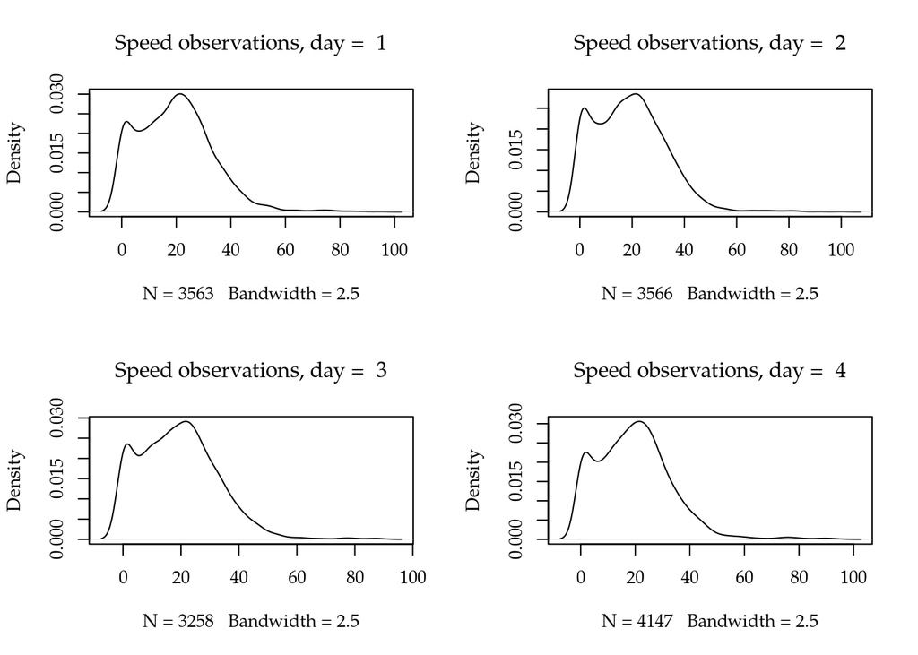

```r
par(mfrow = c(2,2), family = "Palatino")

for (i in 1:4) {
  (data %>% filter(day == i))$speed %>% density(bw = 2.5) %>% plot(main = bquote("Speed observations, day = " ~ .(i)))
}
```

### 1.0.2 Add data and build mesh

Let us add the speed observations to the graph and build the mesh. Observe that `mesh` already has the value of the available covariates on the mesh nodes.

```r
start_time <- Sys.time()
sf_graph$add_observations(data = data, group = "day", clear_obs = TRUE)
sf_graph$build_mesh(h = h)
Sys.sleep(5)
```

# 2 Modeling

### 2.0.1 Stationary model

- Observe that we are considering replicates.

```r
stat.time.ini <- Sys.time()
################################################################################
################################# STATIONARY MODEL #############################
################################################################################

rspde_model_stat <- rspde.metric_graph(sf_graph,
                                         parameterization = "matern",
                                         nu = 0.5)

data_rspde_bru_stat <- graph_data_rspde(rspde_model_stat,
                                        repl = ".all",
                                        loc_name = "loc")

cmp_stat = speed ~ -1 +
  Intercept(1) +
  SpeedLimit +
  #density_per_hour +
  #bus +
  #signal +
  #stop +
  #crossing +
  #upto1_ind +
  #bus_number +
  field(loc, model = rspde_model_stat,
        replicate = data_rspde_bru_stat[["repl"]])

rspde_fit_stat <-
  bru(cmp_stat,
      data = data_rspde_bru_stat[["data"]],
      family = "gaussian",
      options = list(verbose = FALSE)
  )
stat.time.fin <- Sys.time()
print(stat.time.fin - stat.time.ini)
```

```
## Time difference of 33.70123 secs
```

```r
fit.rspde = rspde.result(rspde_fit_stat, "field", rspde_model_stat)

# summaries
# summary(rspde_fit_stat)

rspde_fit_stat$summary.fixed
```

|  | mean | sd | 0.025quant | 0.5quant | 0.975quant | mode | kld |
| --- | --- | --- | --- | --- | --- | --- | --- |
| Intercept | 20.882794 | 0.3740744 | 20.163123 | 20.876637 | 21.637800 | 20.876756 | 8.513480e-08 |
| SpeedLimit | 3.059757 | 0.2799573 | 2.517053 | 3.061362 | 3.597091 | 3.062133 | 4.361886e-07 |

```r
rbind(rspde_fit_stat$summary.hyperpar,
      rspde_fit_stat$summary.hyperpar[1,]^(-0.5),
      summary(fit.rspde))
```

|  | mean | sd | 0.025quant | 0.5quant | 0.975quant | mode |
| --- | --- | --- | --- | --- | --- | --- |
| Precision for the Gaussian observations | 0.01198387 | 1.863015e-04 | 0.01162046 | 0.01198271 | 0.01235397 | 0.01198099 |
| Theta1 for field | 2.85320599 | 7.007147e-02 | 2.71741232 | 2.85247740 | 2.99330140 | 2.84938815 |
| Theta2 for field | -1.08903847 | 2.165014e-01 | -1.50812241 | -1.09144845 | -0.65571082 | -1.10168827 |
| Precision for the Gaussian observations1 | 9.13484982 | 7.326421e+01 | 9.27659058 | 9.13529410 | 8.99697816 | 9.13594925 |
| std.dev | 17.38510000 | 1.214710e+00 | 15.15730000 | 17.32760000 | 19.92530000 | 17.19410000 |
| range | 0.34443400 | 7.539220e-02 | 0.22204900 | 0.33552700 | 0.51696600 | 0.31811700 |

```r
c(unlist(rspde_fit_stat$dic[c("dic", "dic.sat", "p.eff")]),
  unlist(rspde_fit_stat$waic[c("waic", "p.eff")])) |> t() |> as.data.frame()
```

| dic | dic.sat | p.eff | waic | p.eff |
| --- | --- | --- | --- | --- |
| 108508.6 | 17488.76 | 2958.577 | 108688.1 | 2626.612 |

```r
rspde_fit_stat$mlik[2,1]
```

```
## log marginal-likelihood (Gaussian)
##                          -55592.19
```

### 2.0.2 Nonstationary model

- Observe that we are using the computed parameters from the stationary model as initial values for the nonstationary models.

```r
nonstat.time.ini <- Sys.time()
################################################################################
############################# NON STATIONARY MODEL #############################
################################################################################

B.sigma = cbind(0, 1, 0, mesh$SpeedLimit, 0)
B.range = cbind(0, 0, 1, 0, mesh$SpeedLimit)

rspde_model_nonstat <- rspde.metric_graph(sf_graph,
                                            start.theta = c(fit.rspde$summary.log.std.dev$mode,
                                                            fit.rspde$summary.log.range$mode,
                                                            rep(0, 2)),
                                            B.sigma = B.sigma,
                                            B.range = B.range,
                                            parameterization = "matern",
                                            nu = 0.5)

data_rspde_bru_nonstat <- graph_data_rspde(rspde_model_nonstat,
                                        repl = ".all",
                                        loc_name = "loc")

cmp_nonstat = speed ~ -1 +
  Intercept(1) +
  SpeedLimit +
  #density_per_hour +
  #bus +
  #signal +
  #stop +
  #crossing +
  #upto1_ind +
  #bus_number +
  field(loc, model = rspde_model_nonstat,
        replicate = data_rspde_bru_nonstat[["repl"]])

rspde_fit_nonstat <-
  bru(cmp_nonstat,
      data = data_rspde_bru_nonstat[["data"]],
      family = "gaussian",
      options = list(verbose = FALSE)
  )

nonstat.time.fin <- Sys.time()
print(nonstat.time.fin - nonstat.time.ini)
```

```
## Time difference of 36.20956 secs
```

```r
# summaries
# summary(rspde_fit_nonstat)

rspde_fit_nonstat$summary.fixed
```

|  | mean | sd | 0.025quant | 0.5quant | 0.975quant | mode | kld |
| --- | --- | --- | --- | --- | --- | --- | --- |
| Intercept | 20.798579 | 0.4054805 | 20.005038 | 20.796454 | 21.603990 | 20.796439 | 5.051953e-08 |
| SpeedLimit | 2.862864 | 0.2734531 | 2.332193 | 2.861968 | 3.403804 | 2.863043 | 4.534620e-08 |

```r
rbind(rspde_fit_nonstat$summary.hyperpar,
      rspde_fit_nonstat$summary.hyperpar[1,]^(-0.5),
      summary(rspde.result(rspde_fit_nonstat, "field", rspde_model_nonstat)))
```

|  | mean | sd | 0.025quant | 0.5quant | 0.975quant | mode |
| --- | --- | --- | --- | --- | --- | --- |
| Precision for the Gaussian observations | 0.01194285 | 0.000184497 | 0.0115840 | 0.01194134 | 0.01231041 | 0.01193813 |
| Theta1 for field | 3.01115153 | 0.114035728 | 2.7844700 | 3.01189600 | 3.23346692 | 3.01501873 |
| Theta2 for field | -0.72196173 | 0.291877240 | -1.3016708 | -0.72022117 | -0.15245032 | -0.71293070 |
| Theta3 for field | 0.37059213 | 0.119025113 | 0.1335629 | 0.37151402 | 0.60220289 | 0.37539356 |
| Theta4 for field | 0.74130288 | 0.231935462 | 0.2792548 | 0.74315538 | 1.19245814 | 0.75095633 |
| Precision for the Gaussian observations1 | 9.15052523 | 73.621622130 | 9.2911775 | 9.15110529 | 9.01288212 | 9.15233510 |
| Theta1.matern | 3.01115000 | 0.114036000 | 2.7844700 | 3.01190000 | 3.23347000 | 3.01502000 |
| Theta2.matern | -0.72196200 | 0.291877000 | -1.3016700 | -0.72022100 | -0.15245000 | -0.71293100 |
| Theta3.matern | 0.37059200 | 0.119025000 | 0.1335630 | 0.37151400 | 0.60220300 | 0.37539400 |
| Theta4.matern | 0.74130300 | 0.231935000 | 0.2792550 | 0.74315500 | 1.19246000 | 0.75095600 |

```r
c(unlist(rspde_fit_nonstat$dic[c("dic", "dic.sat", "p.eff")]),
  unlist(rspde_fit_nonstat$waic[c("waic", "p.eff")])) |> t() |> as.data.frame()
```

| dic | dic.sat | p.eff | waic | p.eff |
| --- | --- | --- | --- | --- |
| 108518.6 | 17446.9 | 2917.435 | 108699.5 | 2596.968 |

```r
rspde_fit_nonstat$mlik[2,1]
```

```
## log marginal-likelihood (Gaussian)
##                          -55598.78
```

# 3 Cross-validation

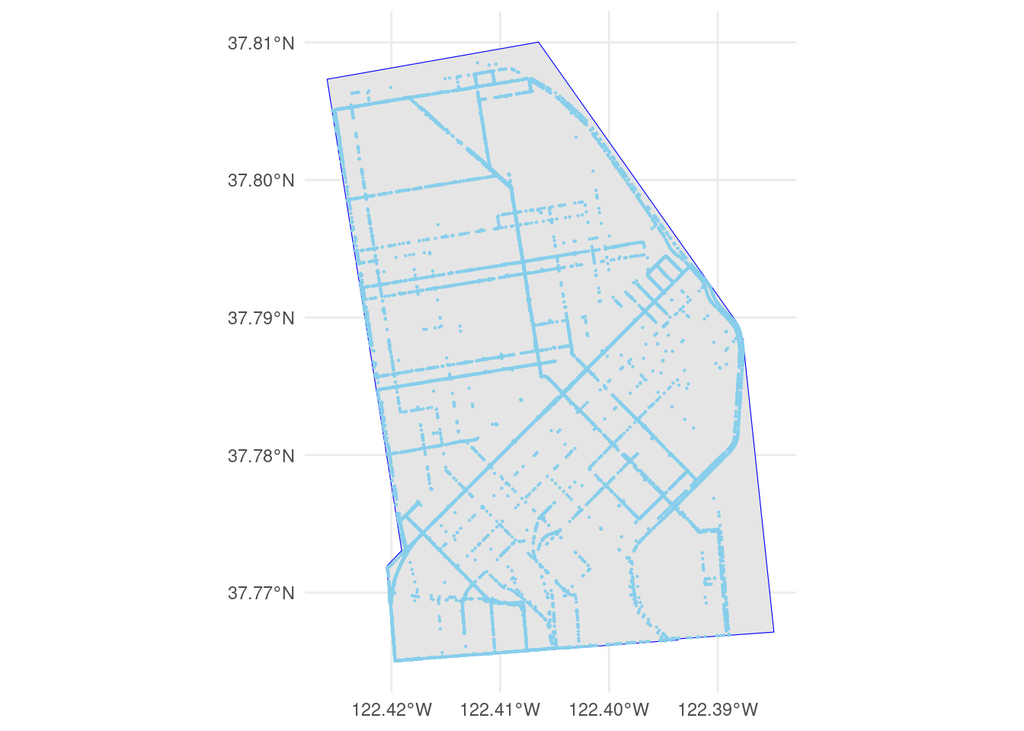

Skyblue points are speed observations.

```r
################################################################################
################################ CROSSVALIDATION ###############################
################################################################################

points = data_on_graph_with_covariates %>%
  as.data.frame() %>%
  st_as_sf(coords = c(".coord_x", ".coord_y"), crs = 4326) %>%
  mutate(., index = 1:nrow(.))

polygon = st_multipoint(c(st_point(c(-122.42591, 37.80732)),
                          st_point(c(-122.40648, 37.81002)),
                          st_point(c(-122.38820, 37.78959)),
                          st_point(c(-122.38770, 37.78849)),
                          st_point(c(-122.38483, 37.76713)),
                          st_point(c(-122.39342, 37.76665)),
                          st_point(c(-122.39372, 37.76655)),
                          st_point(c(-122.41970, 37.76500)),
                          st_point(c(-122.42039, 37.77159)),
                          st_point(c(-122.42050, 37.77174)),
                          st_point(c(-122.42040, 37.77194)),
                          st_point(c(-122.41905, 37.77306)))) %>%
  st_cast("POLYGON") %>%
  st_sfc(crs = st_crs(points))


ggplot() +
  geom_sf(data = polygon, aes(color = "blue"), color = "blue") +
  geom_sf(data = points, aes(color = "skyblue"), color = "skyblue", size = 0.1) +
  theme_minimal()
```

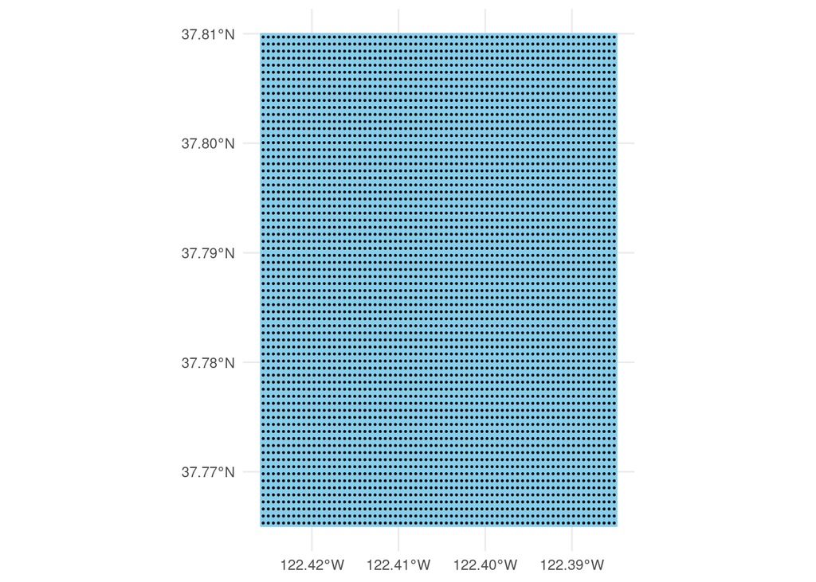

```r
grid100 = st_make_grid(polygon, n = c(300, 300)) %>%
  as.data.frame() %>%
  st_as_sf(crs = st_crs(points)) %>%
  st_centroid() %>%
  mutate(dummy = 1)

grid10 = st_make_grid(polygon, n = c(70, 70)) %>%
  as.data.frame() %>%
  st_as_sf(crs = st_crs(points)) %>%
  st_centroid() %>%
  mutate(dummy = 1)


ggplot() +
  geom_sf(data = polygon, aes(color = "blue"), color = "blue") +
  geom_sf(data = grid100, aes(color = "skyblue"), color = "skyblue", size = 0.1) +
  geom_sf(data = grid10, aes(color = "black"), color = "black", size = 0.2) +
  theme_minimal()
```

```r
get.index = points %>%
  st_join(x = grid100, y = ., join = st_nearest_feature) %>%
  dplyr::select(index) %>%
  st_join(x = grid10, y = ., join = st_nearest_feature) %>%
  dplyr::select(index) %>%
  st_filter(polygon)

################################################################################
########### choose here if all points or some points are included ##############
################################################################################

chosen.points = points[get.index$index, ] %>% dplyr::select(speed)
#chosen.points = points %>% dplyr::select(speed)

data.frame(total.points = nrow(points), chosen.points = nrow(chosen.points))
```

| total.points | chosen.points |
| --- | --- |
| 14534 | 3527 |

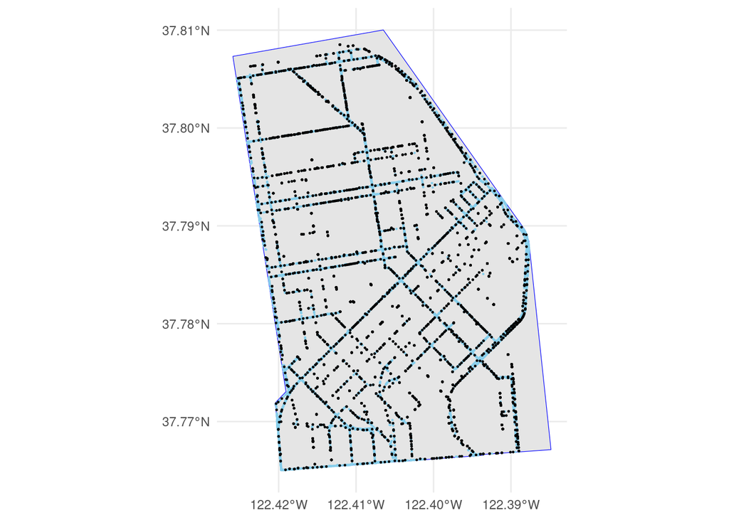

All points are speed observations. Black points are the selected ones.

```r
ggplot() +
  geom_sf(data = polygon, aes(color = "blue"), color = "blue") +
  geom_sf(data = points, aes(color = "skyblue"), color = "skyblue", size = 0.1) +
  geom_sf(data = chosen.points, aes(color = "black"), color = "black", size = 0.2) +
  theme_minimal()
```

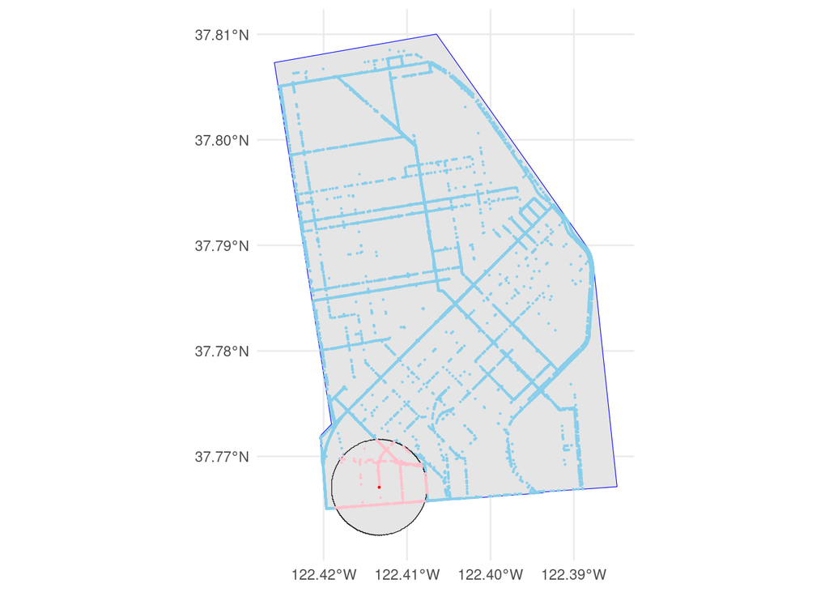

All points are speed observations. The red point is the one under analysis and pink points are removed points.

```r
aux1 = chosen.points[47,2] %>%
  st_buffer(dist = 500, nQuadSegs = 30)

aux2 = aux1 %>%
  st_filter(x = points, y = .)

ggplot() +
  geom_sf(data = polygon, aes(color = "blue"), color = "blue") +
  geom_sf(data = points, aes(color = "skyblue"), color = "skyblue", size = 0.1) +
  geom_sf(data = aux1, aes(color = "black"), color = "black", size = 0.2) +
  geom_sf(data = aux2, aes(color = "pink"), color = "pink", size = 0.1) +
  geom_sf(data = chosen.points[47,2], aes(color = "red"), color = "red", size = 0.2) +
  theme_minimal()
```

```r
distance = seq(from = 0, to = 250, by = 50)
mse.stat <- mse.nonstat <- ls.stat <- ls.nonstat <- rep(0,length(distance))
# cross-validation for-loop
for(j in 1:length(distance)){
  print(j)
  groups <- list()
  for(i in 1:nrow(chosen.points)) {
    # get index of the points that should be removed
    groups[[i]] <- (chosen.points[i,2] %>%
                      st_buffer(dist = distance[j], nQuadSegs = 30) %>%
                      st_filter(x = points, y = .) %>%
                      as.data.frame())$index # as.data.frame is important so that we do not include the geometry column
  }
  # cross-validation of the stationary model
  cv.stat <- inla.group.cv(rspde_fit_stat, groups = groups)
  # cross-validation of the nonstationary model
  cv.nonstat <- inla.group.cv(rspde_fit_nonstat, groups = groups)
  # obtain MSE and LS
  mse.stat[j] <- mean((cv.stat$mean[1:nrow(chosen.points)] - chosen.points$speed)^2)
  mse.nonstat[j] <- mean((cv.nonstat$mean[1:nrow(chosen.points)] - chosen.points$speed)^2)
  ls.stat[j] <- mean(log(cv.stat$cv[1:nrow(chosen.points)]))
  ls.nonstat[j] <- mean(log(cv.nonstat$cv[1:nrow(chosen.points)]))
}
```

```
## [1] 1
## [1] 2
## [1] 3
## [1] 4
## [1] 5
## [1] 6
```

```
## Time difference of 25.5281 mins
```

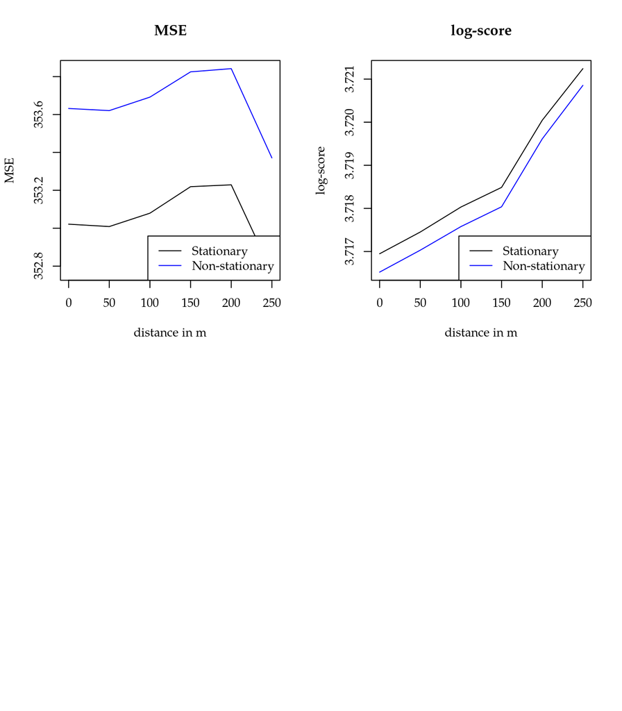

```r
## plot results
par(mfrow = c(2,2), family = "Palatino")

# Plot MSE
plot(distance, mse.stat, main = "MSE", ylim = c(min(mse.nonstat, mse.stat), max(mse.nonstat, mse.stat)),
     type = "l", ylab = "MSE", xlab = "distance in m", col = "black")
lines(distance, mse.nonstat, col = "blue")
legend("bottomright", legend = c("Stationary", "Non-stationary"), col = c("black", "blue"), lty = 1)

# Plot log-score
plot(distance, -ls.stat, main = "log-score", ylim = c(min(-ls.nonstat, -ls.stat), max(-ls.nonstat, -ls.stat)),
     type = "l", ylab = "log-score", xlab = "distance in m", col = "black")
lines(distance, -ls.nonstat, col = "blue")
legend("bottomright", legend = c("Stationary", "Non-stationary"), col = c("black", "blue"), lty = 1)


end_time <- Sys.time()
execution_time <- end_time - start_time
print(execution_time)
```

```r
save.image(here(paste0("Models_output/", rmarkdown::metadata$title, ".RData")))
```